# SAMSI data set

Petra LeBeau

Mon 15 Jul 2019

# 1 Data

## 1.1 Upload raw data and select variables

```r
# Read in raw data and save as RDS
#dd0 <- read_delim("I:/SHARE/USERS/plebeau/CGM/T1D study data/DataTables/HDeviceCGM.txt", delim = "|")
#export(dd0, "I:/SHARE/USERS/plebeau/CGM/T1D study data/DataTables/HDeviceCGM.rds")
dd0 <- readRDS("I:/SHARE/USERS/plebeau/CGM/T1D study data/DataTables/HDeviceCGM.rds") %>%
  janitor::clean_names() %>%
  mutate_if(is.character,as.factor) %>%
  mutate(pt_id=as.factor(pt_id)) %>%
  filter(!record_type %in% c("Calibration"))

# Metadata
#dd1 <- read_delim("I:/SHARE/USERS/plebeau/CGM/T1D study data/DataTables/HScreening.txt", delim = "|")
#export(dd1, "I:/SHARE/USERS/plebeau/CGM/T1D study data/DataTables/HScreening.rds")
dd1 <- readRDS("I:/SHARE/USERS/plebeau/CGM/T1D study data/DataTables/HScreening.rds") %>%
  janitor::clean_names() %>%
  mutate_if(is.character,as.factor) %>%
  mutate(pt_id=as.factor(pt_id)) %>%
  select(c(pt_id, site_id, gender, ethnicity, diag_age, oth_gluc_lower_med, edu_level,
           weight, height, cgm_use_status))

#dd2 <- read_delim("I:/SHARE/USERS/plebeau/CGM/T1D study data/DataTables/HPtRoster.txt", delim = "|")
#export(dd2, "I:/SHARE/USERS/plebeau/CGM/T1D study data/DataTables/HPtRoster.rds")
dd2 <- readRDS("I:/SHARE/USERS/plebeau/CGM/T1D study data/DataTables/HPtRoster.rds") %>%
  janitor::clean_names() %>%
  mutate_if(is.character,as.factor) %>%
  mutate(pt_id=as.factor(pt_id)) %>%
  select(pt_id, pt_status, trt_group, age_as_of_enroll_dt)

ds_subject <- inner_join(dd1,dd2)
export(ds_subject, file="I:/SHARE/USERS/plebeau/CGM/T1D study data/AnalysisData/ds_subject.RDS")

# Visit data
#dd3 <- read_delim("I:/SHARE/USERS/plebeau/CGM/T1D study data/DataTables/HVisitInfo.txt", delim = "|")
#export(dd3, "I:/SHARE/USERS/plebeau/CGM/T1D study data/DataTables/HVisitInfo.rds")
ds_visit <- readRDS("I:/SHARE/USERS/plebeau/CGM/T1D study data/DataTables/HVisitInfo.rds") %>%
  janitor::clean_names() %>%
  mutate_if(is.character,as.factor) %>%
  mutate(pt_id=as.factor(pt_id)) %>%
  filter(visit %in% c('Randomization','Week 3 Visit', 'Week 6 Visit', 'Week 13 Visit',
                      'Week 19 Visit', 'Week 26 Visit')) %>%
  droplevels() %>%
  mutate(visit = fct_relevel(visit, c("Randomization", "Week 3 Visit",
                                        "Week 6 Visit", "Week 13 Visit", "Week 19 Visit", "Week 26 Visit"))) %>%
  mutate(visit_dt_days_from_enroll_lag7 = visit_dt_days_from_enroll - 7) %>%
  mutate(visitnum = fct_recode(visit, "0" = "Randomization",
                            "1" = "Week 3 Visit",
                            "2" = "Week 6 Visit",
                            "3" = "Week 13 Visit",
                            "4" = "Week 19 Visit",
                            "5" = "Week 26 Visit")) %>%
  select(pt_id, visit, visitnum, visit_dt_days_from_enroll, visit_dt_days_from_enroll_lag7)
export(ds_visit, file="I:/SHARE/USERS/plebeau/CGM/T1D study data/AnalysisData/ds_visit.RDS")
```

## 1.2 Assign visits to cgm data

```r
table(ds_visit$visit)
```

```
Randomization  Week 3 Visit  Week 6 Visit Week 13 Visit Week 19 Visit Week 26 Visit
          226           224           224           221           219           217
```

```r
# Get CGM data from 7 days prior to the visit
ds_cgm <- left_join(dd0, ds_visit, by = c("pt_id")) %>%
  filter( (device_dt_tm_days_from_enroll >= visit_dt_days_from_enroll_lag7 &
             device_dt_tm_days_from_enroll <= visit_dt_days_from_enroll) ) %>%
  select(pt_id, visit, visitnum, visit_dt_days_from_enroll_lag7, visit_dt_days_from_enroll,
         device_dt_tm_days_from_enroll, device_tm, glucose_value)

export(ds_cgm, file = "I:/SHARE/USERS/plebeau/CGM/T1D study data/AnalysisData/ds_cgm.RDS")
```

## 1.3 Codebook metadata

ds_subject  
13 Variables 226 Observations

pt_id

| n | missing | distinct |
| --- | --- | --- |
| 226 | 0 | 226 |

lowest : 2 3 5 7 8 , highest: 289 290 291 292 293

site_id

| n | missing | distinct | Info | Mean | Gmd | .05 | .10 | .25 | .50 | .75 | .90 | .95 |
| --- | --- | --- | --- | --- | --- | --- | --- | --- | --- | --- | --- | --- |
| 226 | 0 | 14 | 0.994 | 8.221 | 5.112 | 1.0 | 2.0 | 5.0 | 8.0 | 12.0 | 14.5 | 15.0 |

```
 Value          1     2     3     5     6     7     8     9    10    11    12    13
 Frequency     15    16    17    19    27    14     8    14    15    18    13    12
 Proportion 0.066 0.071 0.075 0.084 0.119 0.062 0.035 0.062 0.066 0.080 0.058 0.053

 Value         14    15
 Frequency     15    23
 Proportion 0.066 0.102
```

gender

| n | missing | distinct |
| --- | --- | --- |
| 226 | 0 | 2 |

```
 Value          F     M
 Frequency    112   114
 Proportion 0.496 0.504
```

ethnicity

| n | missing | distinct |
| --- | --- | --- |
| 226 | 0 | 3 |

```
 Value          Hispanic or Latino Not Hispanic or Latino   Unknown/not reported
 Frequency                       9                    216                      1
 Proportion                  0.040                  0.956                  0.004
```

diag_age

| n | missing | distinct | Info | Mean | Gmd | .05 | .10 | .25 | .50 | .75 | .90 | .95 |
| --- | --- | --- | --- | --- | --- | --- | --- | --- | --- | --- | --- | --- |
| 226 | 0 | 55 | 0.999 | 20.75 | 14.9 | 5.00 | 6.00 | 10.00 | 18.00 | 28.75 | 39.00 | 47.00 |

lowest : 0 1 2 3 4 , highest: 57 58 59 60 61

oth_gluc_lower_med

| n | missing | distinct |
| --- | --- | --- |
| 226 | 0 | 2 |

```
 Value         No   Yes
 Frequency    210    16
 Proportion 0.929 0.071
```

edu_level

| n | missing | distinct |
| --- | --- | --- |
| 221 | 5 | 7 |

Associate Degree (9, 0.041), Bachelor's Degree (110, 0.498), Doctorate Degree (6, 0.027), High school graduate/diploma/GED (8, 0.036), Master's Degree (47, 0.213), Professional Degree (11, 0.050), Some college but no degree (30, 0.136)

weight

| n | missing | distinct | Info | Mean | Gmd | .05 | .10 | .25 | .50 | .75 | .90 | .95 |
| --- | --- | --- | --- | --- | --- | --- | --- | --- | --- | --- | --- | --- |
| 226 | 0 | 177 | 1 | 81.22 | 17.68 | 59.00 | 62.15 | 69.73 | 79.50 | 91.40 | 102.35 | 110.68 |

lowest : 50.0 50.8 54.0 55.2 55.9 , highest: 117.5 118.8 121.0 121.6 121.7

height

| n | missing | distinct | Info | Mean | Gmd | .05 | .10 | .25 | .50 | .75 | .90 | .95 |
| --- | --- | --- | --- | --- | --- | --- | --- | --- | --- | --- | --- | --- |
| 226 | 0 | 108 | 1 | 172.4 | 12.02 | 155.0 | 159.0 | 164.1 | 172.0 | 180.0 | 186.0 | 189.0 |

lowest : 149.0 149.9 152.0 152.4 152.5 , highest: 192.8 193.0 196.0 197.9 198.0

cgm_use_status

| n | missing | distinct |
| --- | --- | --- |
| 226 | 0 | 3 |

```
 Value                       Current In past, but not current
 Frequency                       107                       79
 Proportion                    0.473                    0.350

 Value                         Never
 Frequency                        40
 Proportion                    0.177
```

pt_status

| n | missing | distinct |
| --- | --- | --- |
| 226 | 0 | 2 |

```
 Value      Completed   Dropped
 Frequency        217         9
 Proportion      0.96      0.04
```

trt_group

| n | missing | distinct |
| --- | --- | --- |
| 226 | 0 | 2 |

```
 Value      CGM Only  CGM+BGM
 Frequency       149       77
 Proportion    0.659    0.341
```

age_as_of_enroll_dt

| n | missing | distinct | Info | Mean | Gmd | .05 | .10 | .25 | .50 | .75 | .90 | .95 |
| --- | --- | --- | --- | --- | --- | --- | --- | --- | --- | --- | --- | --- |
| 226 | 0 | 53 | 0.999 | 44 | 15.84 | 25 | 27 | 31 | 43 | 55 | 63 | 67 |

lowest : 19 20 22 24 25 , highest: 71 72 74 75 78

ds_visit  
5 Variables 1331 Observations

pt_id

| n | missing | distinct |
| --- | --- | --- |
| 1331 | 0 | 226 |

lowest : 2 3 5 7 8 , highest: 289 290 291 292 293

visit

| n | missing | distinct |
| --- | --- | --- |
| 1331 | 0 | 6 |

```
 Value      Randomization  Week 3 Visit  Week 6 Visit Week 13 Visit Week 19 Visit
 Frequency            226           224           224           221           219
 Proportion         0.170         0.168         0.168         0.166         0.165

 Value      Week 26 Visit
 Frequency            217
 Proportion         0.163
```

visitnum

| n | missing | distinct |
| --- | --- | --- |
| 1331 | 0 | 6 |

```
 Value          0     1     2     3     4     5
 Frequency    226   224   224   221   219   217
 Proportion 0.170 0.168 0.168 0.166 0.165 0.163
```

visit_dt_days_from_enroll

| n | missing | distinct | Info | Mean | Gmd | .05 | .10 | .25 | .50 | .75 | .90 | .95 |
| --- | --- | --- | --- | --- | --- | --- | --- | --- | --- | --- | --- | --- |
| 1328 | 3 | 256 | 1 | 134 | 79.65 | 30.0 | 49.0 | 76.0 | 119.0 | 195.0 | 243.0 | 254.6 |

lowest : 12 13 14 15 16 , highest: 294 297 315 322 329

visit_dt_days_from_enroll_lag7

| n | missing | distinct | Info | Mean | Gmd | .05 | .10 | .25 | .50 | .75 | .90 | .95 |
| --- | --- | --- | --- | --- | --- | --- | --- | --- | --- | --- | --- | --- |
| 1328 | 3 | 256 | 1 | 127 | 79.65 | 23.0 | 42.0 | 69.0 | 112.0 | 188.0 | 236.0 | 247.6 |

lowest : 5 6 7 8 9 , highest: 287 290 308 315 322

ds_cgm  
8 Variables 2785354 Observations

pt_id

| n | missing | distinct |
| --- | --- | --- |
| 2785354 | 0 | 226 |

lowest : 2 3 5 7 8 , highest: 289 290 291 292 293

visit

| n | missing | distinct |
| --- | --- | --- |
| 2785354 | 0 | 6 |

```
 Value      Randomization  Week 3 Visit  Week 6 Visit Week 13 Visit Week 19 Visit
 Frequency         489014        479416        472970        462985        454468
 Proportion         0.176         0.172         0.170         0.166         0.163

 Value      Week 26 Visit
 Frequency         426501
 Proportion         0.153
```

visitnum

| n | missing | distinct |
| --- | --- | --- |
| 2785354 | 0 | 6 |

```
 Value           0      1      2      3      4      5
 Frequency  489014 479416 472970 462985 454468 426501
 Proportion  0.176  0.172  0.170  0.166  0.163  0.153
```

visit_dt_days_from_enroll_lag7

| n | missing | distinct | Info | Mean | Gmd | .05 | .10 | .25 | .50 | .75 | .90 | .95 |
| --- | --- | --- | --- | --- | --- | --- | --- | --- | --- | --- | --- | --- |
| 2785354 | 0 | 255 | 1 | 125 | 78.91 | 22 | 42 | 68 | 111 | 185 | 231 | 247 |

lowest : 5 6 7 8 9 , highest: 287 290 308 315 322

visit_dt_days_from_enroll

| n | missing | distinct | Info | Mean | Gmd | .05 | .10 | .25 | .50 | .75 | .90 | .95 |
| --- | --- | --- | --- | --- | --- | --- | --- | --- | --- | --- | --- | --- |
| 2785354 | 0 | 255 | 1 | 132 | 78.91 | 29 | 49 | 75 | 118 | 192 | 238 | 254 |

lowest : 12 13 14 15 16 , highest: 294 297 315 322 329

device_dt_tm_days_from_enroll

| n | missing | distinct | Info | Mean | Gmd | .05 | .10 | .25 | .50 | .75 | .90 | .95 |
| --- | --- | --- | --- | --- | --- | --- | --- | --- | --- | --- | --- | --- |
| 2785354 | 0 | 313 | 1 | 128.4 | 78.89 | 26 | 44 | 71 | 114 | 188 | 234 | 251 |

lowest : 5 6 7 8 9 , highest: 325 326 327 328 329

device_tm secs

| n | missing | distinct |
| --- | --- | --- |
| 2785354 | 0 | 86400 |

lowest : 00:00:00 00:00:01 00:00:02 00:00:03 00:00:04 , highest: 23:59:55 23:59:56 23:59:57 23:59:58 23:59:59

glucose_value

| n | missing | distinct | Info | Mean | Gmd | .05 | .10 | .25 | .50 | .75 | .90 | .95 |
| --- | --- | --- | --- | --- | --- | --- | --- | --- | --- | --- | --- | --- |
| 2785354 | 0 | 363 | 1 | 159.1 | 70.32 | 74 | 86 | 112 | 149 | 196 | 245 | 278 |

lowest : 39 40 41 42 43 , highest: 397 398 399 400 401

# 2 Explore data

## 2.1 Drop-outs by treatment group

Should we exclude these from analysis?

```r
table(ds_subject$pt_status,ds_subject$trt_group)
```

```
            CGM Only CGM+BGM
  Completed      142      75
  Dropped          7       2
```

## 2.2 Prior experience with CGM

Could be used for subgroup analyses

```r
table(ds_subject$cgm_use_status, ds_subject$trt_group)
```

```
                           CGM Only CGM+BGM
  Current                        69      38
  In past, but not current       54      25
  Never                          26      14
```

## 2.3 Number of visits with some data per subject

```r
ds_cgmu <- ds_cgm %>%
  group_by(pt_id, visitnum) %>%
  arrange(pt_id, visitnum) %>%
  filter(row_number()==1)
#' Number of subjects
length(unique(ds_cgmu$pt_id))
```

```
[1] 226
```

```r
addmargins(table(ds_cgmu$pt_id, ds_cgmu$visitnum))
```

```
         0    1    2    3    4    5  Sum
  2      1    1    1    1    1    1    6
  3      1    1    1    1    1    1    6
  5      1    1    1    1    0    1    5
  7      1    1    1    1    1    1    6
  8      1    1    1    1    1    1    6
  9      1    1    1    1    1    1    6
  10     1    1    1    1    1    1    6
  11     1    1    1    1    1    1    6
  14     1    1    1    1    1    1    6
  15     1    1    1    1    1    1    6
  16     1    1    1    1    1    1    6
  17     1    1    1    1    1    1    6
  18     1    1    1    1    1    1    6
  19     1    1    1    1    1    1    6
```

[output cut: 213 more lines]

Only a few have missing visits - leave as is?

Next plot shows subjects with data at what visits.

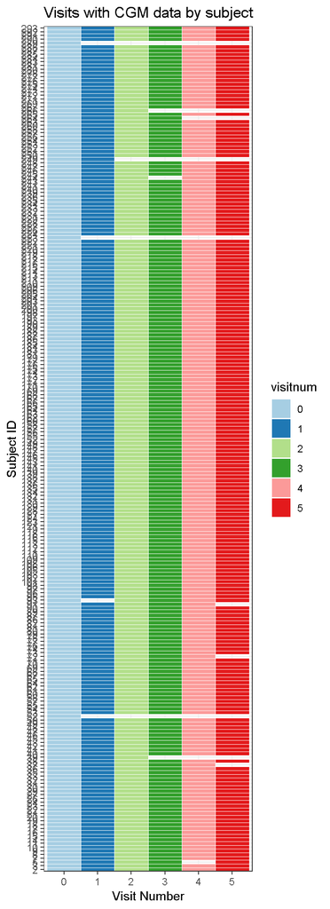

```r
ggplot(ds_cgmu, aes(x=visitnum, y=pt_id, fill=visitnum)) +
  geom_tile(color = "white", size=0.25) +
  scale_y_discrete(expand=c(0,0)) +
  #coord_fixed() +
  scale_fill_brewer(palette = "Paired") +
  theme_bw() +
  labs (title = "Visits with CGM data by subject",
        y = "Subject ID",
        x = "Visit Number")
```

## 2.4 Any unusual data values / no data values?

```r
summary(ds_cgm$glucose_value)
```

```
   Min. 1st Qu.  Median    Mean 3rd Qu.    Max.
   39.0   112.0   149.0   159.1   196.0   401.0
```

## 2.5 Plots for 10 subjects: all visits and prior 7 days to visit

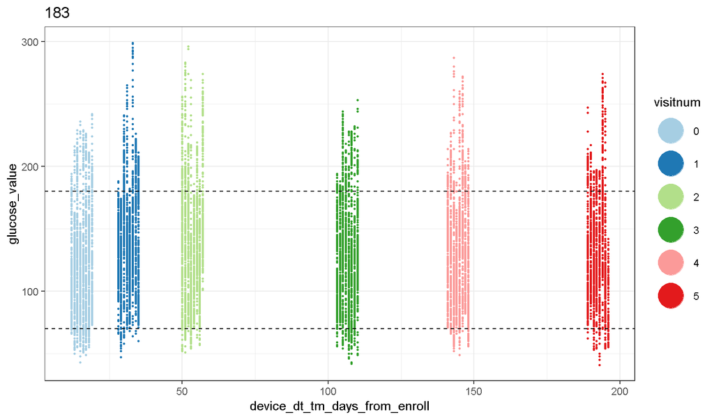

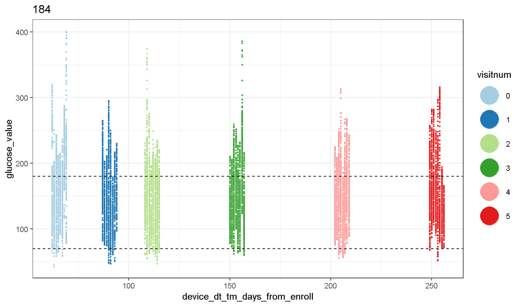

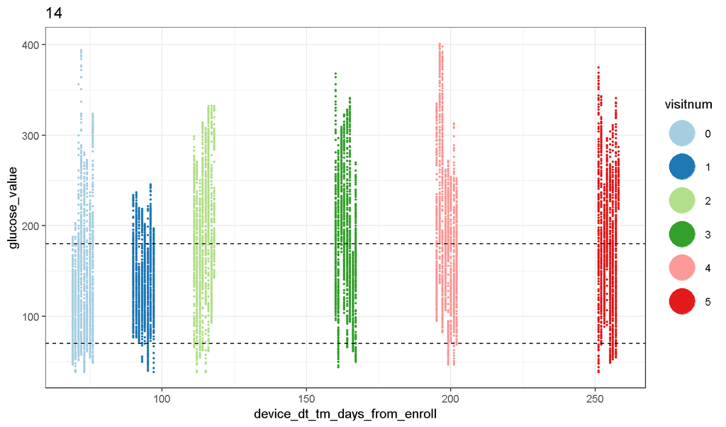

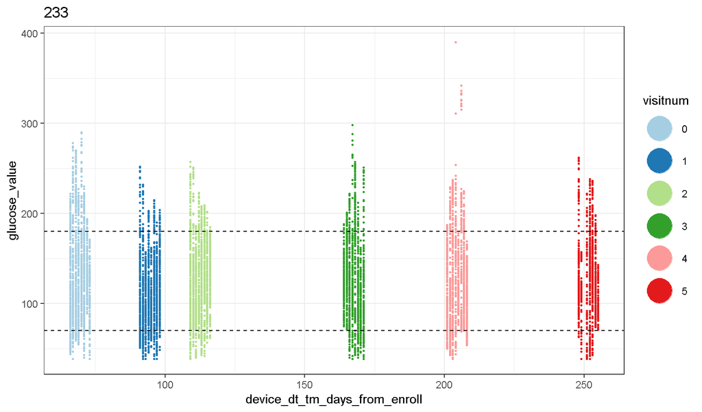

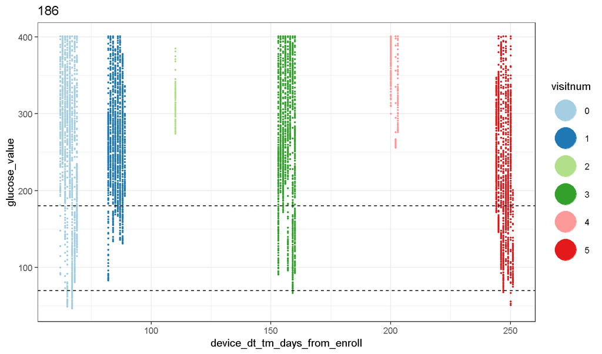

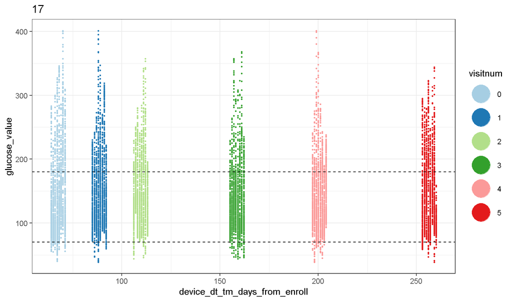

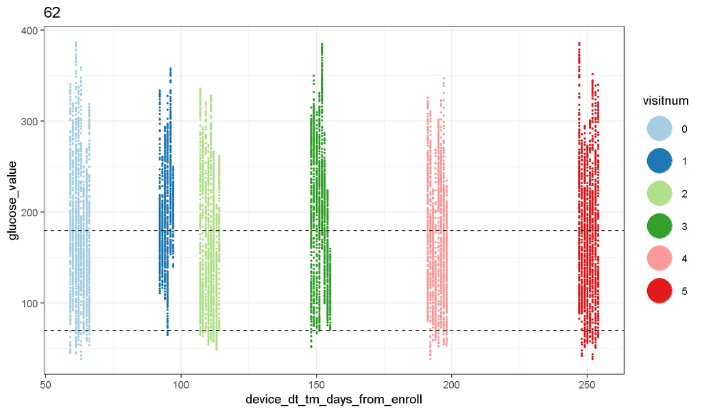

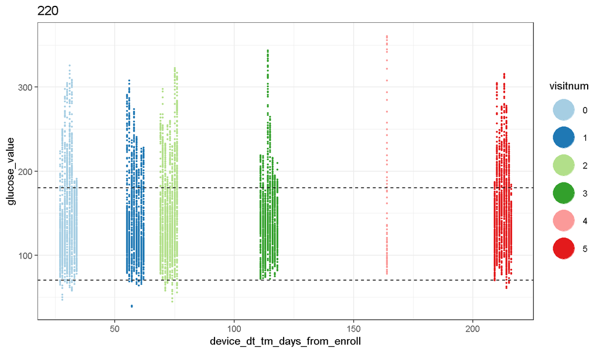

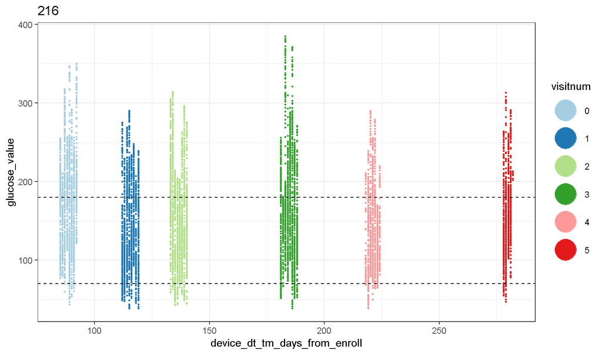

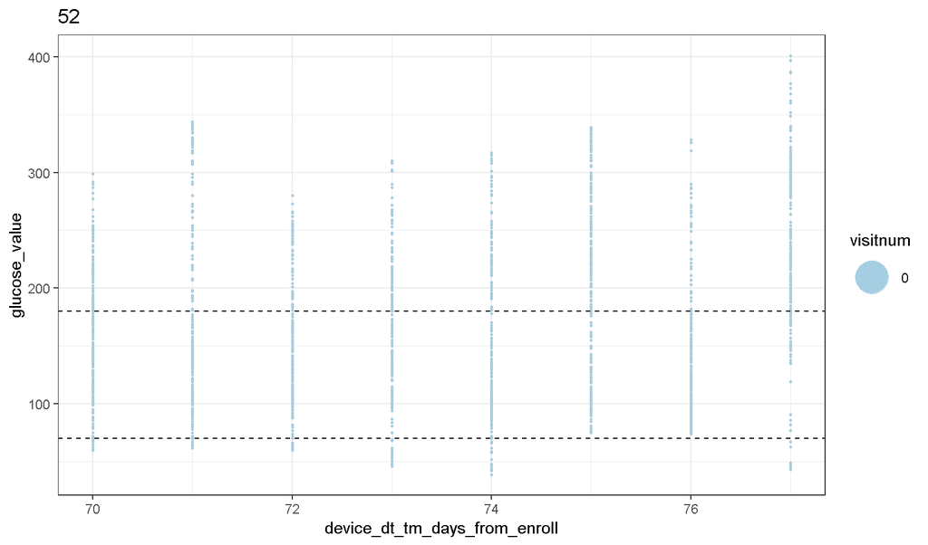

```r
#for (i in unique(dd0_1$pt_id)) {
for (i in unique(ds_cgm$pt_id)[1:10]) {
  p <- ggplot(data = subset(ds_cgm, pt_id == i), aes(x = device_dt_tm_days_from_enroll,
                                                    y = glucose_value, col=visitnum)) +
           geom_point(size=0.5) +
           geom_hline(yintercept=70, color="black", linetype="dashed") +
           geom_hline(yintercept=180, color="black", linetype="dashed") +
           scale_color_brewer(palette = "Paired") +
           theme_bw() +
           #scale_x_date(labels = date_format("%m-%Y")) +
           ggtitle(as.character(i)) +
           guides(col = guide_legend(override.aes = list(size=10)))
  print(p)
}
```

## 2.6 Individual trajectories: 10 subjects, all visitis and prior 7 days to visit

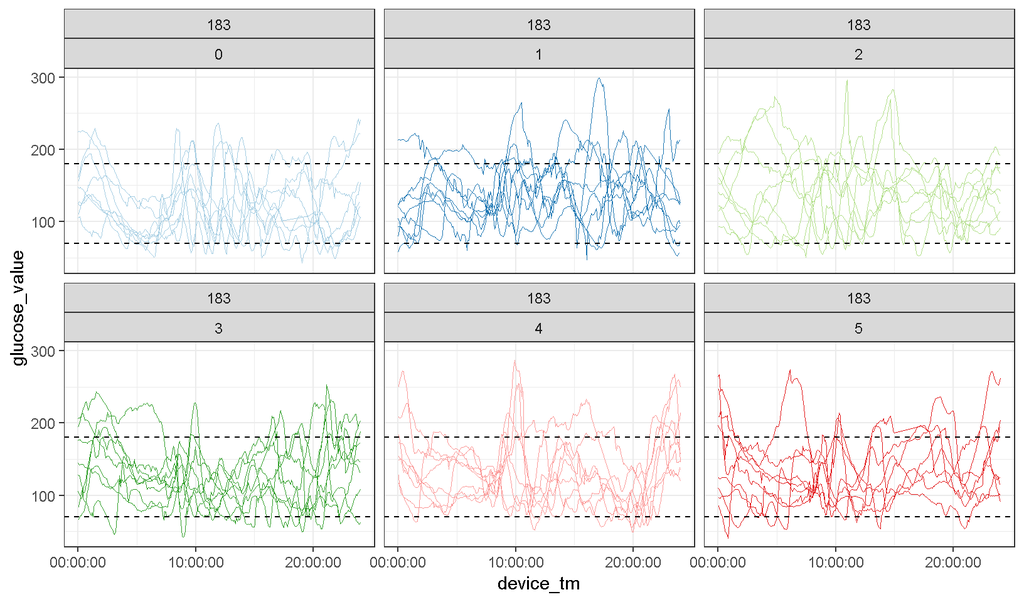

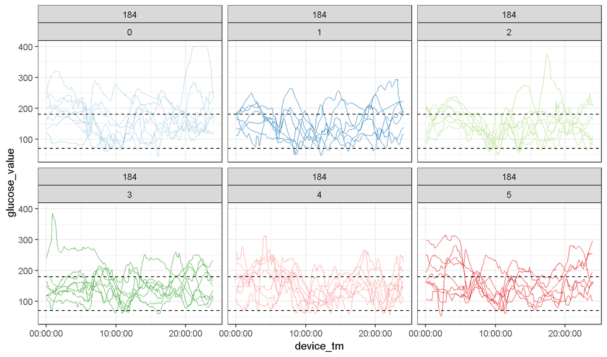

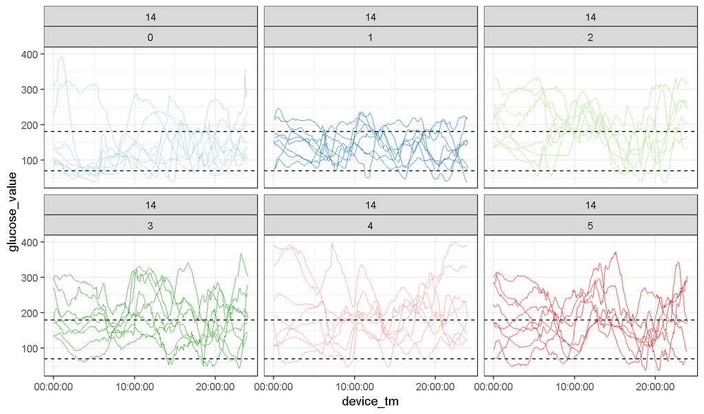

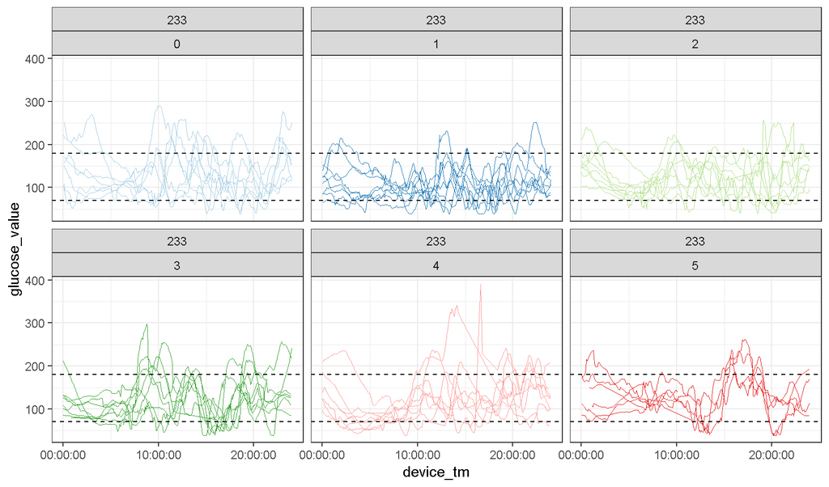

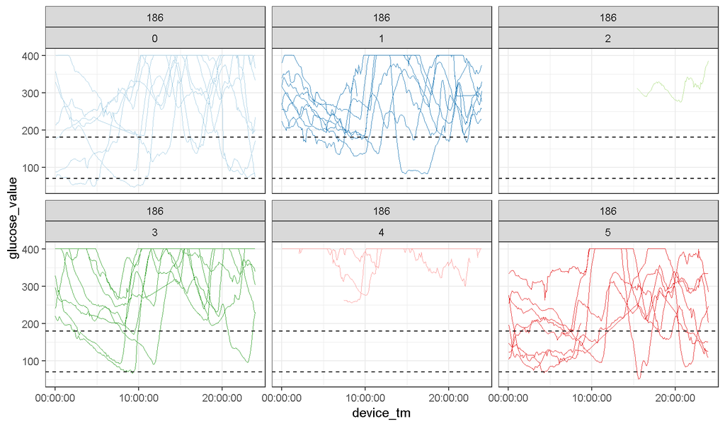

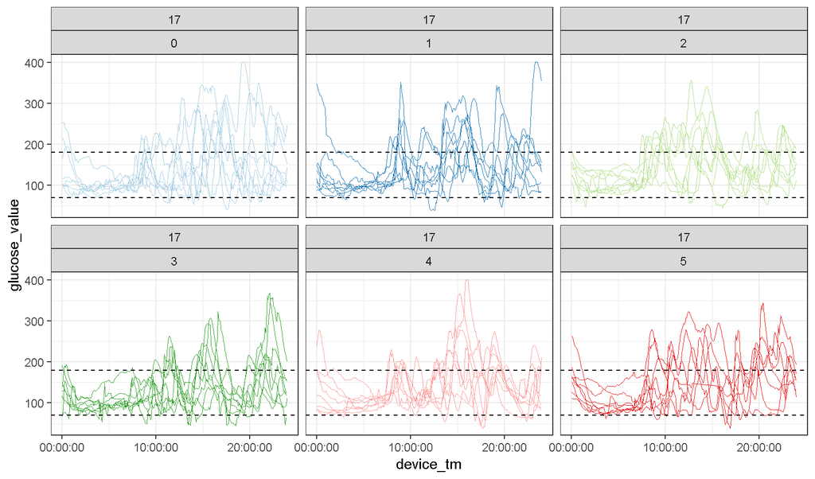

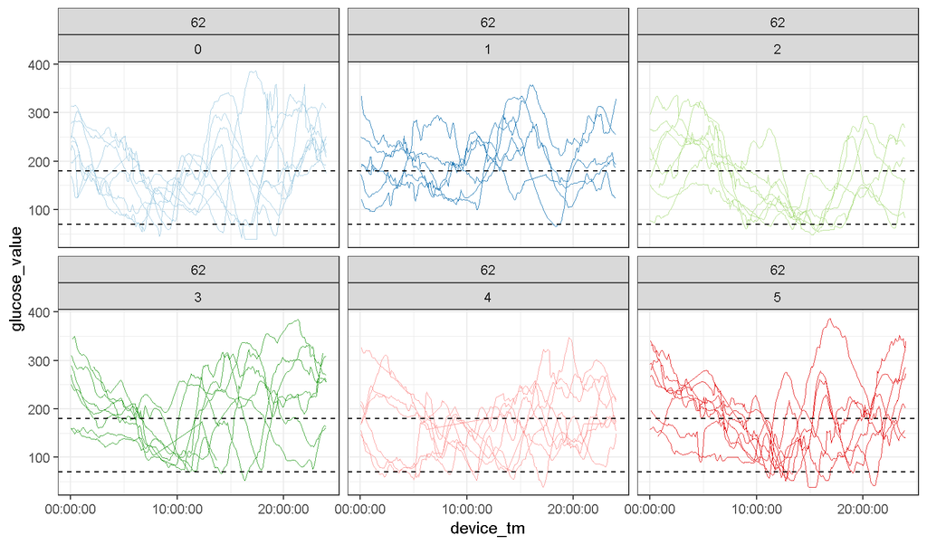

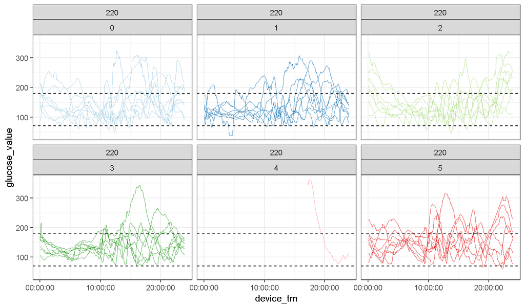

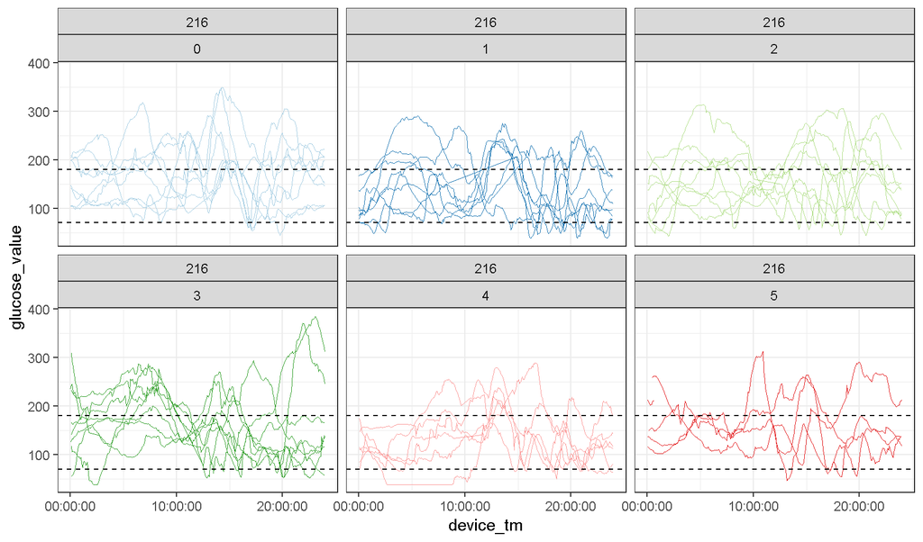

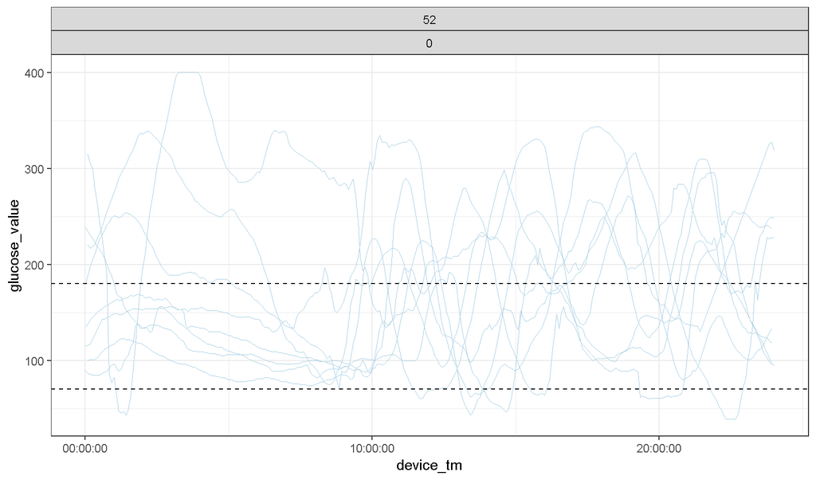

```r
#' Look at individual daily trajectories by visit
for (i in unique(ds_cgm$pt_id)[1:10]) {
  pp <- ggplot(data = subset(ds_cgm, pt_id == i),
               aes(x = device_tm, y = glucose_value, group=as.factor(device_dt_tm_days_from_enroll),
                   col=as.factor(visitnum))) +
    facet_wrap(pt_id~visitnum) +
    geom_line(size=0.1, show.legend=FALSE) +
    theme_bw()+
    geom_hline(yintercept=70, color="black", linetype="dashed") +
    geom_hline(yintercept=180, color="black", linetype="dashed") +
    scale_color_brewer(palette = "Paired")
  print(pp)
}
```

## 2.7 Demographics Table

```r
#Relabel
var.labels <- c(gender = "Gender",
                ethnicity = "Ethnicity",
                diag_age = "Age at Diagnosis",
                oth_gluc_lower_med = "Other Glucose Lowering Medication",
                edu_level = "Highest Education Level",
                weight = "Weight",
                height = "Height",
                cgm_use_status = "CGM Use",
                pt_status = "Completed Study",
                trt_group = "Treatment Group",
                age_as_of_enroll_dt = "Age at Enrollment"
)
ds_subject <- Hmisc::upData(ds_subject, labels = var.labels)
```

```
Input object size:   37968 bytes;    13 variables    226 observations
New object size:    39544 bytes;    13 variables    226 observations
```

```r
compareGroups(trt_group ~ pt_status + gender + ethnicity + diag_age + age_as_of_enroll_dt +
                edu_level + weight + height + cgm_use_status,
              data = ds_subject,
              include.miss = TRUE) %>%
  createTable(show.p.overall = TRUE,
              #hide = c("No"),
              show.n = TRUE) %>%
  export2md(strip = TRUE, first.strip = TRUE)
```

Summary descriptives table by groups of `Treatment Group’

|  | CGM Only | CGM+BGM | p.overall | N |
| --- | --- | --- | --- | --- |
|  | N=149 | N=77 |  |  |
| Completed Study: |  |  | 0.722 | 226 |
| Completed | 142 (95.3%) | 75 (97.4%) |  |  |
| Dropped | 7 (4.70%) | 2 (2.60%) |  |  |
| Gender: |  |  | 0.511 | 226 |
| F | 71 (47.7%) | 41 (53.2%) |  |  |
| M | 78 (52.3%) | 36 (46.8%) |  |  |
| Ethnicity: |  |  | 0.352 | 226 |
| Hispanic or Latino | 4 (2.68%) | 5 (6.49%) |  |  |
| Not Hispanic or Latino | 144 (96.6%) | 72 (93.5%) |  |  |
| Unknown/not reported | 1 (0.67%) | 0 (0.00%) |  |  |
| Age at Diagnosis | 20.8 (13.8) | 20.6 (13.0) | 0.919 | 226 |
| Age at Enrollment | 43.5 (14.1) | 45.0 (13.2) | 0.434 | 226 |
| Highest Education Level: |  |  | 0.300 | 226 |
| Associate Degree | 6 (4.03%) | 3 (3.90%) |  |  |
| Bachelor’s Degree | 75 (50.3%) | 35 (45.5%) |  |  |
| Doctorate Degree | 3 (2.01%) | 3 (3.90%) |  |  |
| High school graduate/diploma/GED | 6 (4.03%) | 2 (2.60%) |  |  |
| Master’s Degree | 29 (19.5%) | 18 (23.4%) |  |  |
| Professional Degree | 6 (4.03%) | 5 (6.49%) |  |  |
| Some college but no degree | 23 (15.4%) | 7 (9.09%) |  |  |
| ‘Missing’ | 1 (0.67%) | 4 (5.19%) |  |  |
| Weight | 82.7 (15.6) | 78.4 (15.6) | 0.053 | 226 |
| Height | 173 (10.6) | 172 (10.4) | 0.792 | 226 |
| CGM Use: |  |  | 0.852 | 226 |
| Current | 69 (46.3%) | 38 (49.4%) |  |  |
| In past, but not current | 54 (36.2%) | 25 (32.5%) |  |  |
| Never | 26 (17.4%) | 14 (18.2%) |  |  |